# Homework 7

NAME HERE

2025-10-24

## Q1

You roll 2 fair, 6-sided dice. Consider the following events:

A: at least one die is even B: the two dice sum to 7 C: one of the dice is divisible by the other

Find each of the following sets

1. Each intersection of all pairs of events (i.e. A∩B, A∩C, B∩C)
2. Each union of all pairs of events (i.e. A∪B, A∪C, B∪C)
3. The intersection of all 3 (i.e. A∩B∩C)
4. The union of all 3 (i.e. A∪B∪C)

```r
# setting up 2 dice :
dice <- expand.grid(die1 = 1:6, die2 = 1:6)

# defining the pre conditions :

A <- subset(dice, die1 %% 2 == 0 | die2 %% 2 == 0)  # at least one die is even

B <- subset(dice, die1 + die2 == 7) # sum to 7

C <- subset(dice, die1 %% die2 == 0 | die2 %% die1 == 0) # one die divisible by the other

# finding the intersections of the dice :

A_inter_B <- merge(A, B) # merged is used to combine two data frames
A_inter_C <- merge(A, C)
B_inter_C <- merge(B, C)

# getting the unions :

A_union_B <- unique(rbind(A, B)) # rbind also combines data frames
A_union_C <- unique(rbind(A, C))
B_union_C <- unique(rbind(B, C))

# intersecting all 3 :
A_inter_B_inter_C <- merge(A_inter_B, C)
A_union_B_union_C <- unique(rbind(A, B, C))

# results of all :

print("A ∩ B:")
```

```
## [1] "A ∩ B:"
```

```r
print(A_inter_B)
```

```
##   die1 die2
## 1    1    6
## 2    2    5
## 3    3    4
## 4    4    3
## 5    5    2
## 6    6    1
```

```r
print("A ∩ C:")
```

```
## [1] "A ∩ C:"
```

```r
print(A_inter_C)
```

```
##    die1 die2
## 1     1    2
## 2     1    4
## 3     1    6
## 4     2    1
## 5     2    2
## 6     2    4
## 7     2    6
## 8     3    6
## 9     4    1
## 10    4    2
## 11    4    4
## 12    6    1
## 13    6    2
## 14    6    3
## 15    6    6
```

```r
print("B ∩ C:")
```

```
## [1] "B ∩ C:"
```

```r
print(B_inter_C)
```

```
##   die1 die2
## 1    1    6
## 2    6    1
```

```r
print("A ∪ B:")
```

```
## [1] "A ∪ B:"
```

```r
print(A_union_B)
```

```
##    die1 die2
## 2     2    1
## 4     4    1
## 6     6    1
## 7     1    2
## 8     2    2
## 9     3    2
## 10    4    2
## 11    5    2
## 12    6    2
## 14    2    3
## 16    4    3
## 18    6    3
## 19    1    4
## 20    2    4
## 21    3    4
## 22    4    4
## 23    5    4
## 24    6    4
## 26    2    5
## 28    4    5
## 30    6    5
## 31    1    6
## 32    2    6
## 33    3    6
## 34    4    6
## 35    5    6
## 36    6    6
```

```r
print("A ∪ C:")
```

```
## [1] "A ∪ C:"
```

```r
print(A_union_C)
```

```
##    die1 die2
## 2     2    1
## 4     4    1
## 6     6    1
## 7     1    2
## 8     2    2
## 9     3    2
## 10    4    2
## 11    5    2
## 12    6    2
## 14    2    3
## 16    4    3
## 18    6    3
## 19    1    4
## 20    2    4
```

[output cut: 20 more lines]

```r
print("B ∪ C:")
```

```
## [1] "B ∪ C:"
```

```r
print(B_union_C)
```

```
##    die1 die2
## 6     6    1
## 11    5    2
## 16    4    3
## 21    3    4
## 26    2    5
## 31    1    6
## 1     1    1
## 2     2    1
## 3     3    1
## 4     4    1
## 5     5    1
## 7     1    2
## 8     2    2
## 10    4    2
## 12    6    2
## 13    1    3
## 15    3    3
## 18    6    3
## 19    1    4
## 20    2    4
## 22    4    4
## 25    1    5
## 29    5    5
## 32    2    6
## 33    3    6
## 36    6    6
```

```r
print("A ∩ B ∩ C:")
```

```
## [1] "A ∩ B ∩ C:"
```

```r
print(A_inter_B_inter_C)
```

```
##   die1 die2
## 1    1    6
## 2    6    1
```

```r
print("A ∪ B ∪ C:")
```

```
## [1] "A ∪ B ∪ C:"
```

```r
print(A_union_B_union_C)
```

```
##    die1 die2
## 2     2    1
## 4     4    1
## 6     6    1
## 7     1    2
## 8     2    2
## 9     3    2
## 10    4    2
## 11    5    2
## 12    6    2
## 14    2    3
## 16    4    3
## 18    6    3
## 19    1    4
## 20    2    4
```

[output cut: 20 more lines]

## Q2

Let $X$ be a discrete random variable with the following PMF:

$$P_X(x)= \begin{cases}0.1 & \text { for } x=0.2 \\ 0.2 & \text {
for } x=0.4 \\ 0.2 & \text { for } x=0.5 \\ 0.3 & \text { for }
x=0.8 \\ 0.2 & \text { for } x=1 \\ 0 & \text { otherwise
}\end{cases}$$

1. Is this a valid PMF? Explain.
2. Find P(X≤0.5).
3. Find P(0.25<X<0.75).
4. Make a plot of the PMF.

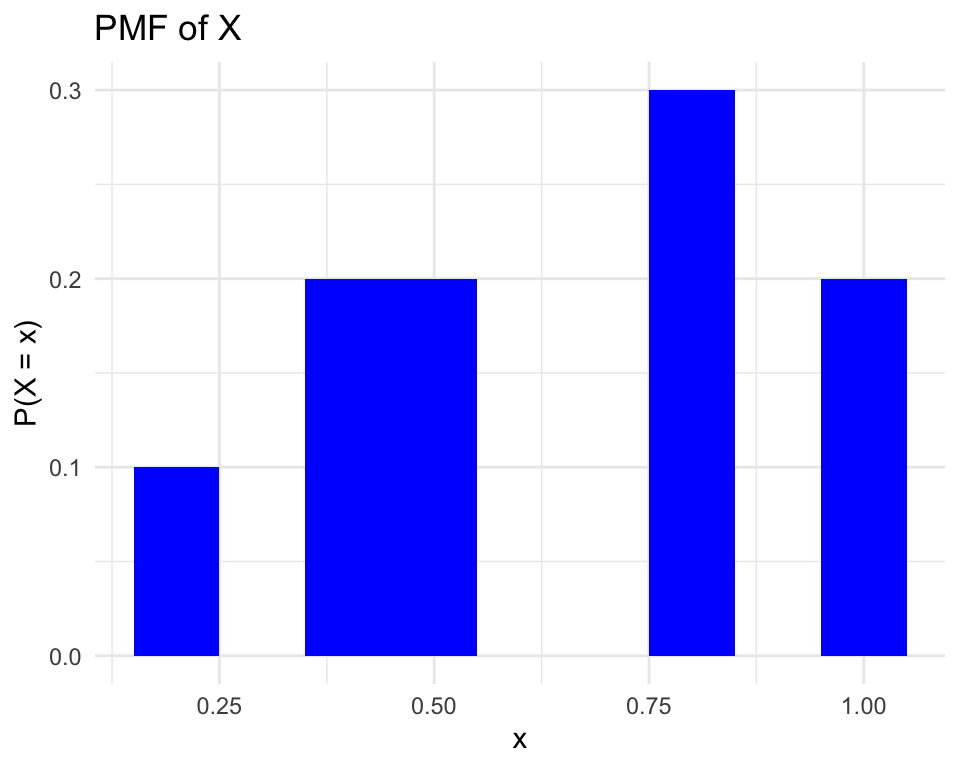

```r
# a. for this to be valid, a probability mass function (PMF) is valid if:
# 1. all of the probabilities are non-negative
# 2. they all sum to 1
# 0.1+0.2+0.2+0.3+0.2= 1 ; therefore, it is VALID.
#VALID


#b. X-values that are less than to equal to 0.5 are : 0.2,0.4,0.5
# P(X≤0.5) = 0.1+0.2+0.2=0.5
# answer : 0.5


#c. Find P(0.25<X<0.75)
# the X-values that are between 0.25 and 0.75
# x = 0.4 and 0.5 ; the number associated with those numbers are 0.2 and 0.2
# 0.2+0.2= 0.4
# answer : 0.4


#plotting :

df <- data.frame(
  x = c(0.2, 0.4, 0.5, 0.8, 1.0),
  p = c(0.1, 0.2, 0.2, 0.3, 0.2)
)

ggplot(df, aes(x = x, y = p)) +
  geom_col(fill = "blue", width = 0.1) +
  labs(title = "PMF of X", x = "x", y = "P(X = x)") +
  theme_minimal()
```

## Q3

Let X,Y be two independent uniform random variables over [0,1], in other words each variable is fairly drawing a real number between 0 and 1. It can be shown that max(X,Y) gives the following pdf (knit to see):

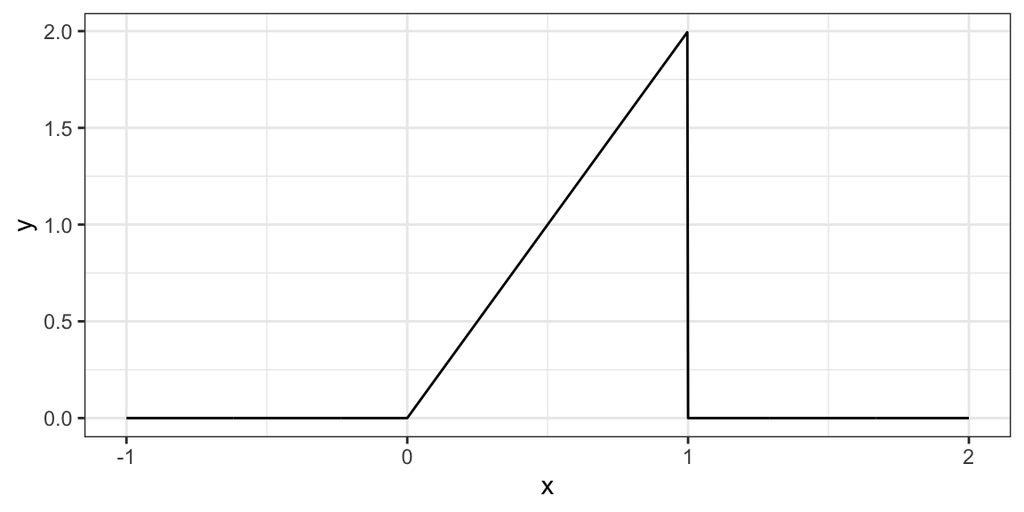

```r
ggplot()+geom_function(fun=\(x)ifelse(0<x&x<1,2*x,0),xlim=c(-1,2),n=1e3)+theme_bw()
```

Find each of the following probabilities (hint: no fancy math necessary, remember probabilities correspond to what on a pdf?)

1. Is this a valid PDF? Explain
2. P( max(X,Y) < 0.5 )
3. P( 0.25 < max(X,Y) < 0.75 )
4. P( max(X,Y) < 0.25 OR 0.75 > max(X,Y) )

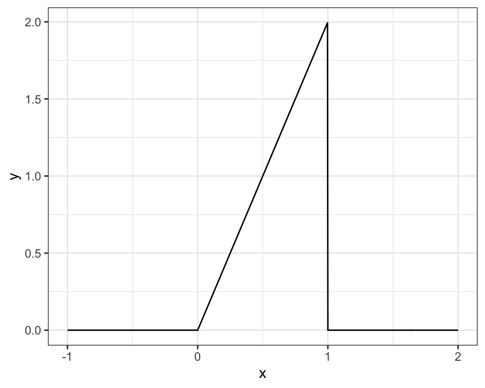

```r
ggplot()+geom_function(fun=\(x)ifelse(0<x&x<1,2*x,0),xlim=c(-1,2),n=1e3)+theme_bw()
```

```r
#a. Yes this is a valid probability density function. The total area under the triangle is 1.


# b. P(max<0.5) ; small triangle, base=0.5 and height is 1.
# 0.5 x 1 is 0.25
# answer = 0.25


# c. Area from 0.25 to 0.75
# (0.5 × 0.75 × 1.5) − (0.5 × 0.25 × 0.5) = 0.5625 − 0.0625
# answer = 0.5


#d. Area up to 0.75 (height = 1.5)
# 0.5 x 0.75 x 1.5
# answer = 0.5625
```